# Bank Marketing Dataset

This dataset contains information about a Portuguese bank marketing campaign. It's goal is to predict if the client will subscribe to a term deposit, indicated by the variable 'y'.

More information about this database can be found at: https://archive.ics.uci.edu/ml/datasets/Bank+Marketing

## Imports

```python
import pandas as pd
import numpy as np
import matplotlib.pyplot as plt
import statsmodels.api as sm
import seaborn as sns
from sklearn.preprocessing import OrdinalEncoder, RobustScaler
from sklearn.ensemble import RandomForestClassifier
from sklearn.svm import SVC
from sklearn.linear_model import LogisticRegression
from sklearn.neighbors import KNeighborsClassifier
from sklearn.model_selection import KFold, train_test_split, cross_val_score, GridSearchCV
from sklearn.pipeline import Pipeline
from scipy import stats
from scipy.stats import norm
from tqdm.notebook import tqdm
import warnings
warnings.filterwarnings('ignore')
plt.style.use('ggplot')
```

## Opening database

```python
df = pd.read_csv('bank-full.csv', sep=';')
df.head(10)
```

|  | age | job | marital | education | default | balance | housing | loan | contact | day | month | duration | campaign | pdays | previous | poutcome | y |
| --- | --- | --- | --- | --- | --- | --- | --- | --- | --- | --- | --- | --- | --- | --- | --- | --- | --- |
| 0 | 58 | management | married | tertiary | no | 2143 | yes | no | unknown | 5 | may | 261 | 1 | -1 | 0 | unknown | no |
| 1 | 44 | technician | single | secondary | no | 29 | yes | no | unknown | 5 | may | 151 | 1 | -1 | 0 | unknown | no |
| 2 | 33 | entrepreneur | married | secondary | no | 2 | yes | yes | unknown | 5 | may | 76 | 1 | -1 | 0 | unknown | no |
| 3 | 47 | blue-collar | married | unknown | no | 1506 | yes | no | unknown | 5 | may | 92 | 1 | -1 | 0 | unknown | no |
| 4 | 33 | unknown | single | unknown | no | 1 | no | no | unknown | 5 | may | 198 | 1 | -1 | 0 | unknown | no |
| 5 | 35 | management | married | tertiary | no | 231 | yes | no | unknown | 5 | may | 139 | 1 | -1 | 0 | unknown | no |
| 6 | 28 | management | single | tertiary | no | 447 | yes | yes | unknown | 5 | may | 217 | 1 | -1 | 0 | unknown | no |
| 7 | 42 | entrepreneur | divorced | tertiary | yes | 2 | yes | no | unknown | 5 | may | 380 | 1 | -1 | 0 | unknown | no |
| 8 | 58 | retired | married | primary | no | 121 | yes | no | unknown | 5 | may | 50 | 1 | -1 | 0 | unknown | no |
| 9 | 43 | technician | single | secondary | no | 593 | yes | no | unknown | 5 | may | 55 | 1 | -1 | 0 | unknown | no |

As we can see, this dataset have a lot of categorical features.

To begin our study, we should have a look at the 'y' distribution.

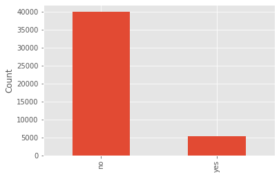

```python
df['y'].value_counts().plot.bar()
plt.ylabel('Count')
plt.show()
```

The plot shows that there are a considerable unbalance between the classes, our model should consider that

## Analyzing the influence of the age

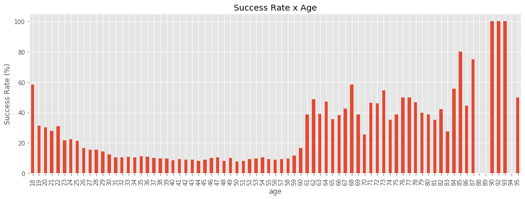

```python
data = df[['age', 'y']]
data['y'] = data['y'].apply(lambda y: 1 if y == 'yes' else 0)
data = data.groupby('age')['y'].mean() * 100
data.plot.bar(figsize=(15, 5), title='Success Rate x Age')
plt.ylabel('Success Rate (%)')
plt.show()
```

With this plot, we can conclude that older people tend to have higher chance tp subscribe to a term deposit. Also, young people can also have a high chance to subscribe, which reduces as the person gets older and get stabilize at 30 years old, growing again only after the 60 years.

## Analyzing the influence of the job

With a similar analysis, we can plot the number of 'yes' per job

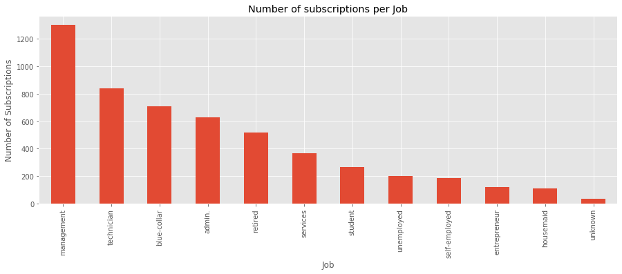

```python
data = df[df['y'] == 'yes'].groupby(df['job'])
N = 12
data['job'].count().nlargest(N).plot.bar(figsize=(15, 5),
                                           title='Number of subscriptions per Job')
plt.grid(True)
plt.ylabel("Number of Subscriptions")
plt.xlabel("Job")
plt.show()
```

As we can see, this plot shows that 'jobs' with a possible economical stability have a higher number of subscriptions, as 'management', 'technician', 'blue-collar' and 'admin'.

## Analyzing the influence of the marital

We will apply the same logic as before

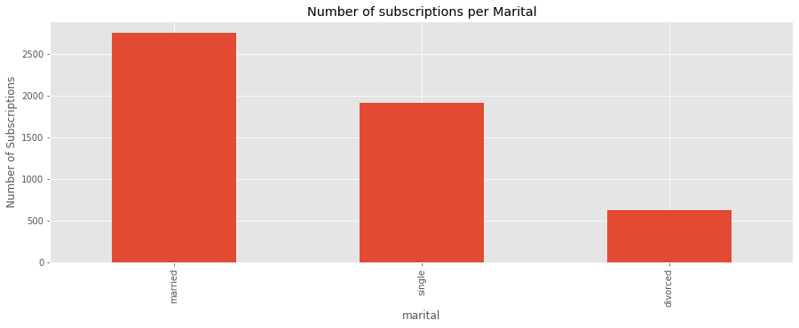

```
Proportion from the biggest number to the second one: 1.4408995815899581
```

```python
data = df[df['y'] == 'yes'].groupby(df['marital'])
N = 3
data['marital'].count().nlargest(N).plot.bar(figsize=(15, 5),
                                           title='Number of subscriptions per Marital')
plt.ylabel("Number of Subscriptions")
plt.show()
print('Proportion from the biggest number to the second one: {}'.format(
      data['marital'].count().nlargest(N)[0] / data['marital'].count().nlargest(N)[1]))
```

## Preprocessing the data

Now, we could analyze the correlation of the variables to have a better knowledge of how much each one is important to predict 'y'.

First, we need to transform the categorical column into numerical:

```python
data = df.copy()
data['loan'] = data['loan'].apply(lambda x: 1 if x == 'yes' else 0)
data['housing'] = data['housing'].apply(lambda x: 1 if x == 'yes' else 0)
data['default'] = data['default'].apply(lambda x: 1 if x == 'yes' else 0)
data['y'] = data['y'].apply(lambda x: 1 if x == 'yes' else 0)
data = pd.get_dummies(data)
```

Now, let's check the skewness of the numerical values

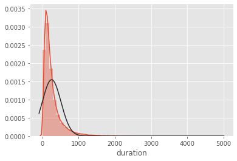

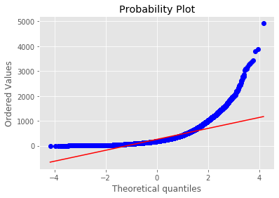

```python
sns.distplot(df['duration'], fit=norm);
fig = plt.figure()
res = stats.probplot(df['duration'], plot=plt)
```

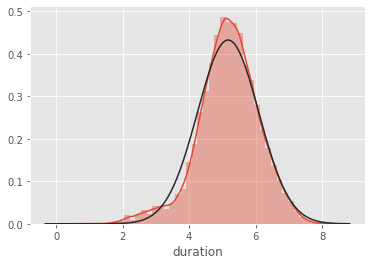

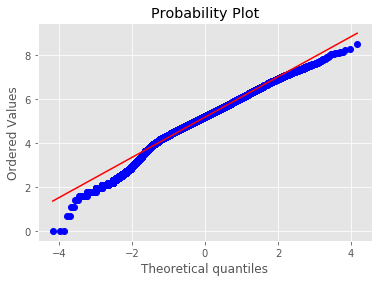

```python
# The data is not in a normal distribution, so let's transform it
data['duration'] = np.log(data['duration'] + 1)
sns.distplot(data['duration'], fit=norm);
fig = plt.figure()
res = stats.probplot(data['duration'], plot=plt)
```

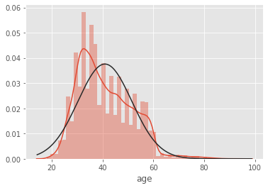

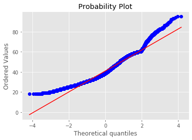

```python
sns.distplot(data['age'], fit=norm)
fig = plt.figure()
res = stats.probplot(data['age'], plot=plt)
```

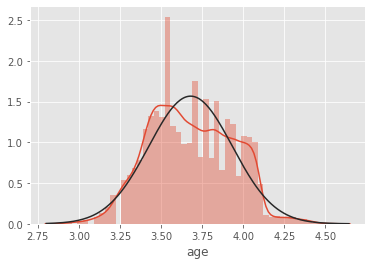

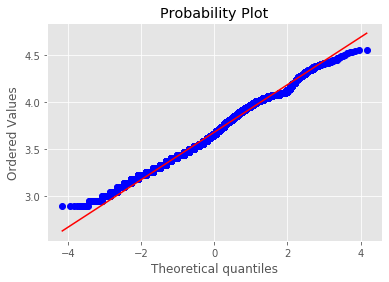

```python
# The data is not in a normal distribution, so let's transform it
data['age'] = np.log(data['age'])
sns.distplot(data['age'], fit=norm)
fig = plt.figure()
res = stats.probplot(data['age'], plot=plt)
```

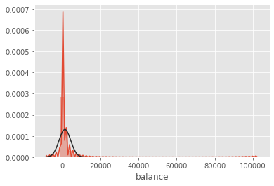

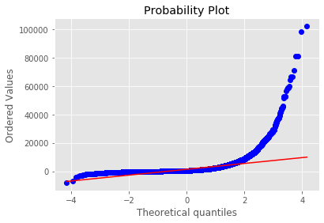

```python
sns.distplot(data['balance'], fit=norm)
fig = plt.figure()
res = stats.probplot(data['balance'], plot=plt)
```

Balance has a lot of zero values, so let's keep it for this study.

Finally, separating the 'y' column:

```python
y_train = data['y']
data = data.drop(columns=['y'])
```

[output not shown]

## Defining the model

For this study, we will test the acuraccy of some classifiers, like RandomForest, kNN, SVC and LogistcRegression.

Our final model will be the best between those

```python
def model_precision(model):
    kf = KFold(n_folds, shuffle=True).get_n_splits(data.values)
    score = cross_val_score(model, data.values, y_train, scoring='accuracy', cv = kf, n_jobs=-1)
    return(score)
```

```python
params = {
    'n_estimators':[50, 100, 150, 200, 250],
    'max_depth': [None, 2, 3, 4, 5]
}
forest = Pipeline([('scaler', RobustScaler()),
                   ('model', GridSearchCV(RandomForestClassifier(n_jobs=-1), params))])
params = {'kernel':('linear', 'rbf'), 'C':range(1, 10)}
svc = Pipeline([('scaler', RobustScaler()),
                ('model', GridSearchCV(SVC(class_weight='balanced', max_iter=1000, gamma='scale'), params))])
params = {'n_neighbors' : range(3, 10)}
knn = Pipeline([('scaler', RobustScaler()),
                ('model', GridSearchCV(KNeighborsClassifier(n_jobs=-1), params))])
logistic = Pipeline([('scaler', RobustScaler()), ('model', LogisticRegression(class_weight='balanced', n_jobs=-1))])

models = [forest, svc, knn, logistic]
n_folds = 5
```

```python
precision = [model_precision(model) for model in tqdm(models)]
```

[output not shown]

[output cut: 27 more lines]

[output not shown]

```python
precision = [np.mean(score) for score in precision]
final_precision = max(precision)
print('Final model accuracy-score: {:.2f}%'.format(final_precision))
```

[output not shown]